# Introdução

```
Titanic é um nome que para muitas pessoas soa familiar, seja lembrando como um dos maiores acidentes nauticos da história ou como um filme sucesso de bilheteria e vencedor de incríveis onze prêmios Oscar. O foco aqui não será em relação ao filme e sim ao histórico naufrágio, onde no dia 14 de abril de 1912 ele colidiu em um iceberg às 23h40 min e naufragando na madrugada, de acordo com estimativas 2208 pessoas a bordo entre passageiros e tripulantes.
Este trabalho visa através de análise de dados responder a uma principal pergunta: quais foram os fatores que fizeram com que algumas pessoas fossem mais propensas a sobreviver?
```

## Quais foram os fatores que fizeram com que algumas pessoas fossem mais propensas a sobreviver?

```
Antes de conseguir responder a principal pergunta, foi preciso elaborar algumas perguntas direcionadoras para nos guiar em nossa análise de dados, abaixo algumas perguntas que foram feitas:
* Quantas pessoas sobreviveram/morreram?
* As crianças tiveram prioridade nos botes de resgate? E quanto as mulheres?
* Os mais ricos receberam prioridade no resgate?
```

## O inicio da nossa investigação

```
O inicio compreende apenas em importar alguns pacotes de trabalho e o nosso banco de dados relacionado a 891 passageiros dentre as 2208, e para facilitar os nomes das colunas foram editadas tudo para letras em minúsculo.
```

```python
import pandas as pd
import numpy as np
import matplotlib.pyplot as plt
%matplotlib inline

df_titanic = pd.read_csv('titanic-data-6.csv')
df_titanic.head(1)
```

|  | PassengerId | Survived | Pclass | Name | Sex | Age | SibSp | Parch | Ticket | Fare | Cabin | Embarked |
| --- | --- | --- | --- | --- | --- | --- | --- | --- | --- | --- | --- | --- |
| 0 | 1 | 0 | 3 | Braund, Mr. Owen Harris | male | 22.0 | 1 | 0 | A/5 21171 | 7.25 | NaN | S |

```python
df_titanic.rename(columns=lambda x: x.strip().lower(), inplace=True)
df_titanic.head(1)
```

|  | passengerid | survived | pclass | name | sex | age | sibsp | parch | ticket | fare | cabin | embarked |
| --- | --- | --- | --- | --- | --- | --- | --- | --- | --- | --- | --- | --- |
| 0 | 1 | 0 | 3 | Braund, Mr. Owen Harris | male | 22.0 | 1 | 0 | A/5 21171 | 7.25 | NaN | S |

## Analisando a qualidade dos nossos dados

[output not shown]

```python
df_titanic.info()
```

```
<class 'pandas.core.frame.DataFrame'>
RangeIndex: 891 entries, 0 to 890
Data columns (total 12 columns):
passengerid    891 non-null int64
survived       891 non-null int64
pclass         891 non-null int64
name           891 non-null object
sex            891 non-null object
age            714 non-null float64
sibsp          891 non-null int64
parch          891 non-null int64
ticket         891 non-null object
fare           891 non-null float64
cabin          204 non-null object
embarked       889 non-null object
dtypes: float64(2), int64(5), object(5)
memory usage: 83.6+ KB
```

Coluna cabin retirado

```python
df_titanic.drop(['cabin'], axis=1, inplace=True)
```

Verificando dados duplicados

```python
df_titanic.duplicated().sum()
```

```
0
```

Preenchendo campos vazios da coluna age com sua média aritmética.

```python
df_titanic['age'].fillna(df_titanic['age'].mean(), inplace=True)
df_titanic['age'] = df_titanic['age'].astype(int)
df_titanic.info()
```

```
<class 'pandas.core.frame.DataFrame'>
RangeIndex: 891 entries, 0 to 890
Data columns (total 11 columns):
passengerid    891 non-null int64
survived       891 non-null int64
pclass         891 non-null int64
name           891 non-null object
sex            891 non-null object
age            891 non-null int32
sibsp          891 non-null int64
parch          891 non-null int64
ticket         891 non-null object
fare           891 non-null float64
embarked       889 non-null object
dtypes: float64(1), int32(1), int64(5), object(4)
memory usage: 73.2+ KB
```

**Nota:** passageiros com menos de 1 ano apresentou valores representados por "0.67" e durante a conversão de float para int foram arredondados para baixo representando "0", porém não afetou em nada já que foi trabalhado com intervalos de idade.

```python
df_titanic.describe()
```

|  | passengerid | survived | pclass | age | sibsp | parch | fare |
| --- | --- | --- | --- | --- | --- | --- | --- |
| count | 891.000000 | 891.000000 | 891.000000 | 891.000000 | 891.000000 | 891.000000 | 891.000000 |
| mean | 446.000000 | 0.383838 | 2.308642 | 29.544332 | 0.523008 | 0.381594 | 32.204208 |
| std | 257.353842 | 0.486592 | 0.836071 | 13.013778 | 1.102743 | 0.806057 | 49.693429 |
| min | 1.000000 | 0.000000 | 1.000000 | 0.000000 | 0.000000 | 0.000000 | 0.000000 |
| 25% | 223.500000 | 0.000000 | 2.000000 | 22.000000 | 0.000000 | 0.000000 | 7.910400 |
| 50% | 446.000000 | 0.000000 | 3.000000 | 29.000000 | 0.000000 | 0.000000 | 14.454200 |
| 75% | 668.500000 | 1.000000 | 3.000000 | 35.000000 | 1.000000 | 0.000000 | 31.000000 |
| max | 891.000000 | 1.000000 | 3.000000 | 80.000000 | 8.000000 | 6.000000 | 512.329200 |

```
O gráfico de correlações mostrou algumas correlações fracas e desprezíveis.
```

```python
df_titanic.corr()
```

|  | passengerid | survived | pclass | age | sibsp | parch | fare |
| --- | --- | --- | --- | --- | --- | --- | --- |
| passengerid | 1.000000 | -0.005007 | -0.035144 | 0.033741 | -0.057527 | -0.001652 | 0.012658 |
| survived | -0.005007 | 1.000000 | -0.338481 | -0.067809 | -0.035322 | 0.081629 | 0.257307 |
| pclass | -0.035144 | -0.338481 | 1.000000 | -0.335071 | 0.083081 | 0.018443 | -0.549500 |
| age | 0.033741 | -0.067809 | -0.335071 | 1.000000 | -0.232743 | -0.176744 | 0.093856 |
| sibsp | -0.057527 | -0.035322 | 0.083081 | -0.232743 | 1.000000 | 0.414838 | 0.159651 |
| parch | -0.001652 | 0.081629 | 0.018443 | -0.176744 | 0.414838 | 1.000000 | 0.216225 |
| fare | 0.012658 | 0.257307 | -0.549500 | 0.093856 | 0.159651 | 0.216225 | 1.000000 |

Funções filtros sobreviventes e mortos Argumentos: data frame retorna linhas cujos campo sobreviventes é 1 para função sobreviventes ou 0 para função não sobreviventes

```python
def survived(df):
    return df.query('survived == 1')
def no_survived(df):
    return df.query('survived == 0')
```

Funções filtros idades Argumentos: data frame retorna linhas cujo campo idade compreende os intervalos definidos em cada função.

```python
def child(df):
    return df.query('age < 18')
def adult(df):
    return df.query('age >= 18 & age < 40')
def middle_age(df):
    return df.query('age >= 40 & age < 60')
def old(df):
    return df.query('age >= 60')
```

Funções filtros sexo Argumentos: data frame retorna linhas cujo campo sexo compreende masculino ou feminino de acordo com a função.

```python
def male(df):
    return df.query('sex == "male"')
def female(df):
    return df.query('sex == "female"')
```

Funções filtros classes Argumentos: data frame retorna linhas cujo campo classe compreende primeira, segunda ou terceira de acordo com cada função. .

```python
def f_class(df):
    return df.query('pclass == 1')
def s_class(df):
    return df.query('pclass == 2')
def t_class(df):
    return df.query('pclass == 3')
```

Funções filtros local de embarque Argumentos: data frame retorna linhas cujo campo embarcado compreende southampton, cherbourg e queenstown de acordo com cada função.

```python
def southampton(df):
    return df.query('embarked == "S"')
def cherbourg(df):
    return df.query('embarked == "C"')
def queenstown(df):
    return df.query('embarked == "Q"')
```

## Traçando um perfil dos passageiros

### Sexo

```
A grande maioria dos passageiros eram do sexo masculino, 577 homens contra 314 mulheres.
```

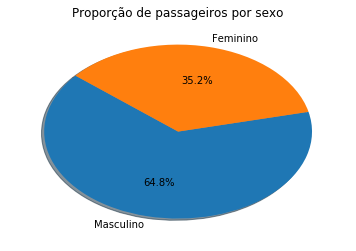

```python
sizes = [male(df_titanic).shape[0], female(df_titanic).shape[0]]
labels = ['Masculino', 'Feminino']
plt.pie(sizes, labels=labels, autopct='%1.1f%%', shadow=True, startangle=140)
plt.title('Proporção de passageiros por sexo');
```

### Idades

```
As idades por apresentar um grande range como pode se observar no gráfico de dispersão, foi adotado o critério de separ por faixas etárias:
- passageiros com 17 anos ou menos foram considerados grupo de crianças;
- passageiros entre 18 anos e 39 anos foram considerados grupo de adultos;
- passageiros entre 40 e 59 anos foram considerados grupo de adultos de meia idade;
- passageiros com 60 anos ou mais foram considerados grupo de idosos;
As observações foram
- grande maioria dos passageiros se encontrava entre as idades entre 18 e 39 anos;
- a média geral foi de 30 anos;
- presença de bebês com menos de 1 ano de idade;
- maior idade foi de 80 anos.
```

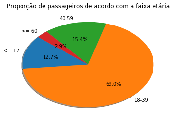

```python
plt.title('Proporção de passageiros de acordo com a faixa etária')
sizes = [child(df_titanic).shape[0], adult(df_titanic).shape[0], middle_age(df_titanic).shape[0], old(df_titanic).shape[0]]
labels = ['<= 17', '18-39', '40-59', '>= 60']
plt.pie(sizes, labels=labels, autopct='%1.1f%%', shadow=True, startangle=140);
```

```python
df_titanic['age'].describe()
```

```
count    891.000000
mean      29.544332
std       13.013778
min        0.000000
25%       22.000000
50%       29.000000
75%       35.000000
max       80.000000
Name: age, dtype: float64
```

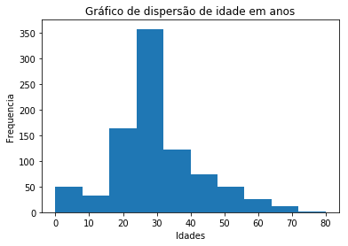

```python
df_titanic['age'].plot(kind='hist', title='Gráfico de dispersão de idade em anos')
plt.ylabel('Frequencia')
plt.xlabel('Idades');
```

### Idade x Sexo

```
Tanto o feminino quanto o masculino apresentaram resultados de distribuição bem similar a distribuição geral por idade.
```

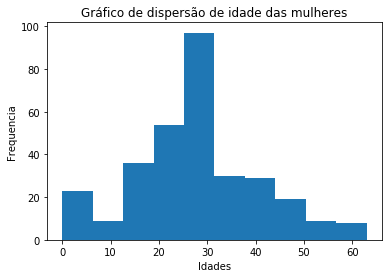

```python
female(df_titanic)['age'].plot(kind='hist',title='Gráfico de dispersão de idade das mulheres')
plt.ylabel('Frequencia')
plt.xlabel('Idades');
```

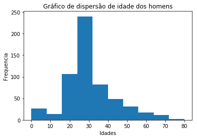

```python
male(df_titanic)['age'].plot(kind='hist', title='Gráfico de dispersão de idade dos homens')
plt.ylabel('Frequencia')
plt.xlabel('Idades');
```

### Classes

```
As passagens eram divididas em três classes: primeira, segunda e terceira, sendo a de primeira classe o direito a áreas exclusivas e maior luxo e em contrapartida a terceira classe era a mais simples e limitadas com presenças de pessoas com objetivos de imigração. As observações foram:
-o grupo predominante era a de terceira classe;
-a quantidade de passageiros entre a primeira e segunda classe foram de proporções próximas.
```

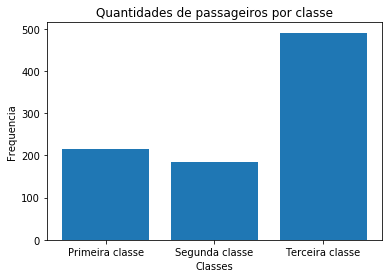

```python
plt.title('Quantidades de passageiros por classe')
plt.xlabel('Classes')
plt.ylabel('Frequencia')
x = [1, 2, 3]
heights = [f_class(df_titanic).shape[0], s_class(df_titanic).shape[0], t_class(df_titanic).shape[0]]
labels = ['Primeira classe', 'Segunda classe', 'Terceira classe']
plt.bar(x, heights, tick_label=labels);
```

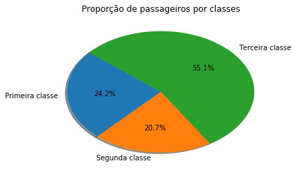

```python
sizes = [f_class(df_titanic).shape[0], s_class(df_titanic).shape[0], t_class(df_titanic).shape[0]]
labels = ['Primeira classe', 'Segunda classe', 'Terceira classe']
plt.title('Proporção de passageiros por classes')
plt.pie(sizes, labels=labels, autopct='%1.1f%%', shadow=True, startangle=140);
```

### Classes x Sexo

```
Nota-se que na terceira classe a grande proporção é de homens, na primeira e segunda classe a proporção de homens e mulheres são bem proxima.
```

**Nota:** homens em azul e mulheres em laranja, não encontrei maneira de colocar legenda

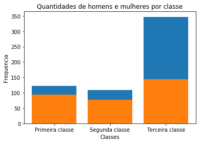

```python
plt.title('Quantidades de homens e mulheres por classe')
plt.xlabel('Classes')
plt.ylabel('Frequencia')
x = [1, 2, 3]
heights = [f_class(male(df_titanic)).shape[0], s_class(male(df_titanic)).shape[0], t_class(male(df_titanic)).shape[0]]
plt.bar(x, heights, tick_label=labels);
heights = [f_class(female(df_titanic)).shape[0], s_class(female(df_titanic)).shape[0], t_class(female(df_titanic)).shape[0]]
labels = ['Primeira classe', 'Segunda classe', 'Terceira classe']
plt.bar(x, heights, tick_label=labels);
```

### Onde embarcaram

```
A grande maioria dos passageiros embarcaram na cidade de Southampton, Inglaterra, de acordo com essa informação podemos supor que a maioria dos passageiros eram ingleses.
```

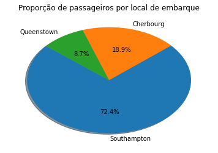

```python
plt.title('Proporção de passageiros por local de embarque')
labels = ['Southampton', 'Cherbourg', 'Queenstown']
heights = [southampton(df_titanic).shape[0], cherbourg(df_titanic).shape[0], queenstown(df_titanic).shape[0]]
plt.pie(heights, labels=labels, autopct='%1.1f%%', shadow=True, startangle=140);
```

## Análisando os sobreviventes e mortos

```
Vamos agora analisar as informações em relação a quem sobreviveu e morreu baseando em três fatores, faixa de idade, sexo e classe. A decisão por essas três variáveis foi que elas estão fortemente ligados as perguntas direcionadoras feitas anteriormente, e embora talvez as demais variáveis possam ser valiosas para uma proposta de um modelo mais complexo e preciso esse não é o escopo deste trabalho.
É bem impactante quando olhamos para a quantidade de sobreviventes, apenas 342 passageiros ou 38.4%, fato que marcou a história da navegação e influênciou os dias atuais em relação a normas marítimas e de construção naval.
```

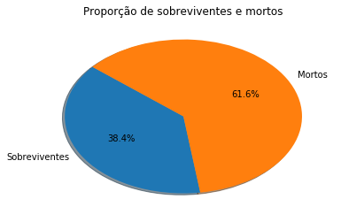

```python
plt.title('Proporção de sobreviventes e mortos')
sizes = [survived(df_titanic).shape[0], no_survived(df_titanic).shape[0]]
labels = ['Sobreviventes', 'Mortos']
plt.pie(sizes, labels=labels, autopct='%1.1f%%', shadow=True, startangle=140);
```

## Procurando por respostas

```
Comparando o gráfico abaixo com o gráfico de faixa etária em relação a todos os passageiros, os dois são muito similares, a proporção se mantem muito proxima para todas as faixas de idade, outra observação é que a maior parte dos sobreviventes compreendem a faixa entre 18 e 39 anos, porém essa faixa já era predominante em relação a todos os passageiros, ao analisar a relação mortes por sobrevivente a faixa etária entre 18 e 39 anos foi de 1,8 mortes por sobrevivente, e dado a quantidade de passageiros nessa faixa, é um resultado muito impactante, enquanto para faixa de 0 e 17 anos temos 0,85 morte por sobrevivente, uma relação bem melhor.
```

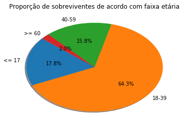

```python
sizes = [child(survived(df_titanic)).shape[0], adult(survived(df_titanic)).shape[0],
         middle_age(survived(df_titanic)).shape[0], old(survived(df_titanic)).shape[0]]
labels = ['<= 17', '18-39', '40-59', '>= 60']
plt.title('Proporção de sobreviventes de acordo com faixa etária')
plt.pie(sizes, labels=labels, autopct='%1.1f%%', shadow=True, startangle=140);
```

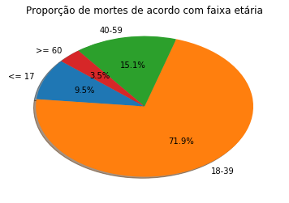

```python
sizes = [child(no_survived(df_titanic)).shape[0], adult(no_survived(df_titanic)).shape[0],
         middle_age(no_survived(df_titanic)).shape[0], old(no_survived(df_titanic)).shape[0]]
labels = ['<= 17', '18-39', '40-59', '>= 60']
plt.title('Proporção de mortes de acordo com faixa etária')
plt.pie(sizes, labels=labels, autopct='%1.1f%%', shadow=True, startangle=140);
```

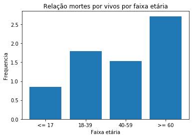

```python
x = [1, 2, 3, 4]
labels = ['<= 17', '18-39', '40-59', '>= 60']
heights = [child(no_survived(df_titanic)).shape[0]/child(survived(df_titanic)).shape[0],
          adult(no_survived(df_titanic)).shape[0]/adult(survived(df_titanic)).shape[0],
          middle_age(no_survived(df_titanic)).shape[0]/middle_age(survived(df_titanic)).shape[0],
          old(no_survived(df_titanic)).shape[0]/old(survived(df_titanic)).shape[0]]
plt.title('Relação mortes por vivos por faixa etária')
plt.bar(x,heights, tick_label=labels)
plt.xlabel('Faixa etária')
plt.ylabel('Frequencia');
```

```
O gráfico abaixo responde uma das perguntas direcionadoras, sim, as mulheres tiveram prioridades no resgate.
```

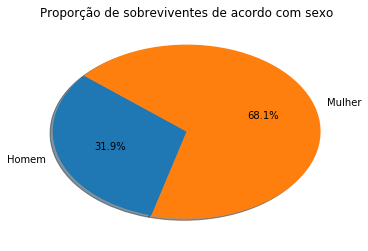

```python
sizes = [male(survived(df_titanic)).shape[0], female(survived(df_titanic)).shape[0]]
labels = ['Homem', 'Mulher']
plt.title('Proporção de sobreviventes de acordo com sexo')
plt.pie(sizes, labels=labels, autopct='%1.1f%%', shadow=True, startangle=140);
```

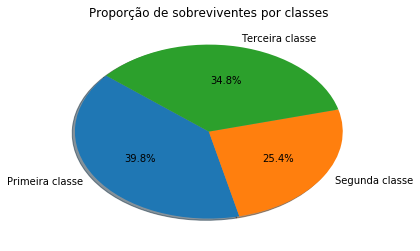

```python
sizes = [f_class(survived(df_titanic)).shape[0], s_class(survived(df_titanic)).shape[0], t_class(survived(df_titanic)).shape[0]]
labels = ['Primeira classe', 'Segunda classe', 'Terceira classe']
plt.title('Proporção de sobreviventes por classes')
plt.pie(sizes, labels=labels, autopct='%1.1f%%', shadow=True, startangle=140);
```

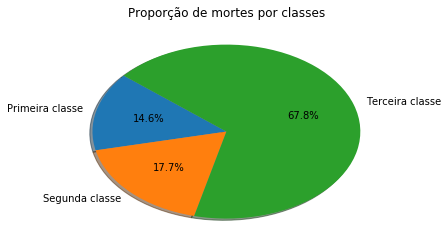

```python
sizes = [f_class(no_survived(df_titanic)).shape[0], s_class(no_survived(df_titanic)).shape[0], t_class(no_survived(df_titanic)).shape[0]]
labels = ['Primeira classe', 'Segunda classe', 'Terceira classe']
plt.title('Proporção de mortes por classes')
plt.pie(sizes, labels=labels, autopct='%1.1f%%', shadow=True, startangle=140);
```

```
  Nota: Azul e cian representam a faixa da primeira classe, vermelho e magenta representam a faixa da segunda classe e preto e verde represetam a faixa da terceira classe
```

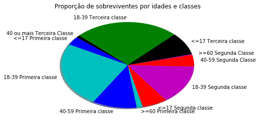

```python
sizes = [child(f_class(survived(df_titanic))).shape[0], adult(f_class(survived(df_titanic))).shape[0],
         middle_age(f_class(survived(df_titanic))).shape[0], old(f_class(survived(df_titanic))).shape[0],
         child(s_class(survived(df_titanic))).shape[0], adult(s_class(survived(df_titanic))).shape[0],
         middle_age(s_class(survived(df_titanic))).shape[0], old(s_class(survived(df_titanic))).shape[0],
         child(t_class(survived(df_titanic))).shape[0], adult(t_class(survived(df_titanic))).shape[0],
         middle_age(t_class(survived(df_titanic))).shape[0] + old(t_class(survived(df_titanic))).shape[0]]
labels = ['<=17 Primeira classe', '18-39 Primeira classe', '40-59 Primeira classe', '>=60 Primeira classe',
          '<=17 Segunda classe', '18-39 Segunda classe', '40-59 Segunda Classe', '>=60 Segunda Classe',
          '<=17 Terceira classe', '18-39 Terceira classe', '40 ou mais Terceira Classe']
colors = ['blue', 'c', 'b', 'c', 'r','m', 'r', 'm', 'black', 'g', 'black']
plt.title('Proporção de sobreviventes por idades e classes')
plt.pie(sizes, labels=labels, shadow=True, startangle=140, colors=colors);
print('  Nota: Azul e cian representam a faixa da primeira classe, vermelho e magenta representam a faixa da segunda classe e preto e verde represetam a faixa da terceira classe')
```

```
Legenda:
1 - <=17 Primeira classe
2 - 18-39 Primeira classe
3 - 40-59 Primeira classe
4 - >=60 Primeira classe
5 - <=17 Segunda classe
6 - 18-39 Segunda classe
7 - 40-59 Segunda Classe
8 - >=60 Segunda Classe
9 - <=17 Terceira classe
10 - 18-39 Terceira classe
11 - 40-59 Terceira classe
12 - >=60 Terceira Classe
```

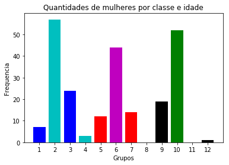

```python
plt.title('Quantidades de mulheres por classe e idade')
x = [1, 2, 3, 4 , 5, 6, 7, 8, 9, 10, 11 ,12]
heights = [female(child(f_class(survived(df_titanic)))).shape[0], female(adult(f_class(survived(df_titanic)))).shape[0],
         female(middle_age(f_class(survived(df_titanic)))).shape[0], female(old(f_class(survived(df_titanic)))).shape[0],
         female(child(s_class(survived(df_titanic)))).shape[0], female(adult(s_class(survived(df_titanic)))).shape[0],
         female(middle_age(s_class(survived(df_titanic)))).shape[0], female(old(s_class(survived(df_titanic)))).shape[0],
         female(child(t_class(survived(df_titanic)))).shape[0], female(adult(t_class(survived(df_titanic)))).shape[0],
         female(middle_age(t_class(survived(df_titanic)))).shape[0], female(old(t_class(survived(df_titanic)))).shape[0]]
print('Legenda:\n1 - <=17 Primeira classe\n2 - 18-39 Primeira classe\n3 - 40-59 Primeira classe\n4 - >=60 Primeira classe')
print('5 - <=17 Segunda classe\n6 - 18-39 Segunda classe\n7 - 40-59 Segunda Classe\n8 - >=60 Segunda Classe')
print('9 - <=17 Terceira classe\n10 - 18-39 Terceira classe\n11 - 40-59 Terceira classe\n12 - >=60 Terceira Classe')

colors = ['blue', 'c', 'b', 'c', 'r','m', 'r', 'm', 'black', 'g', 'g','black']
plt.ylabel('Frequencia')
plt.xlabel('Grupos')
plt.bar(x, heights, label=labels, color=colors, tick_label=x);
```

```
Legenda:
1 - <=17 Primeira classe
2 - 18-39 Primeira classe
3 - 40-59 Primeira classe
4 - >=60 Primeira classe
5 - <=17 Segunda classe
6 - 18-39 Segunda classe
7 - 40-59 Segunda Classe
8 - >=60 Segunda Classe
9 - <=17 Terceira classe
10 - 18-39 Terceira classe
11 - 40-59 Terceira classe
12 - >=60 Terceira Classe
```

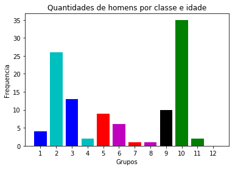

```python
plt.title('Quantidades de homens por classe e idade')
x = [1, 2, 3, 4 , 5, 6, 7, 8, 9, 10, 11 ,12]
heights = [male(child(f_class(survived(df_titanic)))).shape[0], male(adult(f_class(survived(df_titanic)))).shape[0],
         male(middle_age(f_class(survived(df_titanic)))).shape[0], male(old(f_class(survived(df_titanic)))).shape[0],
         male(child(s_class(survived(df_titanic)))).shape[0], male(adult(s_class(survived(df_titanic)))).shape[0],
         male(middle_age(s_class(survived(df_titanic)))).shape[0], male(old(s_class(survived(df_titanic)))).shape[0],
         male(child(t_class(survived(df_titanic)))).shape[0], male(adult(t_class(survived(df_titanic)))).shape[0],
         male(middle_age(t_class(survived(df_titanic)))).shape[0], male(old(t_class(survived(df_titanic)))).shape[0]]
print('Legenda:\n1 - <=17 Primeira classe\n2 - 18-39 Primeira classe\n3 - 40-59 Primeira classe\n4 - >=60 Primeira classe')
print('5 - <=17 Segunda classe\n6 - 18-39 Segunda classe\n7 - 40-59 Segunda Classe\n8 - >=60 Segunda Classe')
print('9 - <=17 Terceira classe\n10 - 18-39 Terceira classe\n11 - 40-59 Terceira classe\n12 - >=60 Terceira Classe')

colors = ['blue', 'c', 'b', 'c', 'r','m', 'r', 'm', 'black', 'g', 'g','black']
plt.ylabel('Frequencia')
plt.xlabel('Grupos')
plt.bar(x, heights, label=labels, color=colors, tick_label=x);
```

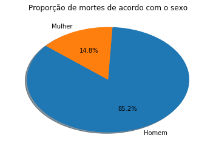

```python
sizes = [male(no_survived(df_titanic)).shape[0], female(no_survived(df_titanic)).shape[0]]
labels = ['Homem', 'Mulher']
plt.title('Proporção de mortes de acordo com o sexo')
plt.pie(sizes, labels=labels, autopct='%1.1f%%', shadow=True, startangle=140);
```

# Limitações

```
Antes de realizar as conclusões vamos deixar claro algumas limitações deste trabalho.
- As conclusões abaixo foram de acordo com inferências do autor ao observar os dados e produzir gráficos, e em nenhum momento foi elaborado ou proposto um modelo preciso e probabilistico;
- O campo age (idade) apresentaram 20% de dados em branco, com objetivo de não deslocar o gráfico de distribuição foi obtado por completar os dados em branco com o valor da média, 29 anos;
- O campo cabin (cabine) apresentou 80% de dados em branco, portanto foi retirado da análise;
- O campo embarked (embarcado) apresentou 2 dados em branco, como essa caracteristica não foi profundamente avaliado não foi tomado nenhuma atitude em relação aos dados em branco;
- Embora os campos sibsp, parch e fare talvez possam contribuir para um modelo muito mais preciso e responder algumas perguntas interessanes, o autor não realizou nenhum aprofundamento.
```

# Conclusões

```
Respondendo nossa principal pergunta "Quais foram os fatores que fizeram com que algumas pessoas fossem mais propensas a sobreviver?"as três variáveis (sexo, classe e idade) foram fatores que influênciaram, sendo o fator sexo o fator mais forte e idade a mais fraca, essa conclusão é graças as seguintes observações:
- O maior número de sobreviventes é composto por mulheres, dentre os 342 sobreviventes 233 eram mulheres ou 68%, uma relação de 2,88 mulheres sobreviventes para cada uma que morreu,
- A primeira classe foram privilegiados no resgate, dentre os sobreviventes 136 passageiros ou 40% pertenciam a primeira classe, uma relação de 1,7 sobrevivente para cada morte
- A relação de sobreviventes por mortos foi melhor dentre os passageiros com 17 anos ou menos, a relação foi de 1,2.
```

Abaixo um relatório demostrando relações de mortes por sobreviventes que resultaram nas observações acima.

```python
#relação geral: mortes por vivo
print('Total de sobreviventes: {0} pessoas \nMorreram: {1} pessoas'.format(
        survived(df_titanic).shape[0], no_survived(df_titanic).shape[0]))
print('{0:.2f} pessoas morreram para cada sobrevivente'.format(no_survived(df_titanic).shape[0]/survived(df_titanic).shape[0]))

#relação geeral entre mulheres: mortes por vivos
print('\nTotal de mulheres: {0}\nSobreviveram: {1}\nMorreram: {2}\n{3:.2f} mulheres morreram para cada uma que sobreviveu'.format(
    female(df_titanic).shape[0], female(survived(df_titanic)).shape[0], female(no_survived(df_titanic)).shape[0],
      female(no_survived(df_titanic)).shape[0]/female(survived(df_titanic)).shape[0]))
print('ou {0: .2f} mulheres sobreviveram para cada uma que morreu'. format(
    female(survived(df_titanic)).shape[0]/female(no_survived(df_titanic)).shape[0]))

#relação geral entre homens: mortes por vivos
print('\nTotal de homens: {0} \nSobreviveram: {1}\nMorreram: {2}\n{3:.2f} homens morreram para cada uma que sobreviveu'.format(
    male(df_titanic).shape[0], male(survived(df_titanic)).shape[0], male(no_survived(df_titanic)).shape[0],
      male(no_survived(df_titanic)).shape[0]/male(survived(df_titanic)).shape[0]))

#relação geral entre primeira classe
print('\nPrimeira Classe:\nSobreviveram: {0} pessoas \nMorreram: {1} pessoas'.format(
        f_class(survived(df_titanic)).shape[0], f_class(no_survived(df_titanic)).shape[0]))
print('{0:.2f} pessoas morreram para cada sobrevivente'.format(
    f_class(no_survived(df_titanic)).shape[0]/f_class(survived(df_titanic)).shape[0]))

#relação geral entre segunda classe
print('\nSegunda Classe:\nSobreviveram: {0} pessoas \nMorreram: {1} pessoas'.format(
        s_class(survived(df_titanic)).shape[0], s_class(no_survived(df_titanic)).shape[0]))
print('{0:.2f} pessoas morreram para cada sobrevivente'.format(
    s_class(no_survived(df_titanic)).shape[0]/s_class(survived(df_titanic)).shape[0]))

#relação geral entre terceira classe
print('\nTerceira Classe:\nSobreviveram: {0} pessoas \nMorreram: {1} pessoas'.format(
        t_class(survived(df_titanic)).shape[0], t_class(no_survived(df_titanic)).shape[0]))
print('{0:.2f} pessoas morreram para cada sobrevivente'.format(
    t_class(no_survived(df_titanic)).shape[0]/t_class(survived(df_titanic)).shape[0]))

#relação entre 0 e 17 anos: mortes por vivo
print('\nEntre 0 e 17 anos: \nSobreviveram: {0} pessoas \nMorreram: {1} pessoas'.format(
    child(survived(df_titanic)).shape[0], child(no_survived(df_titanic)).shape[0]))
print('{0:.2f} pessoas morreram para cada sobrevivente'.format(
    child(no_survived(df_titanic)).shape[0]/child(survived(df_titanic)).shape[0]))

#relação entre 18 e 39 anos: mortes por vivo
print('\nEntre 18 e 39 anos: \nSobreviveram: {0} pessoas \nMorreram: {1} pessoas'.format(
    adult(survived(df_titanic)).shape[0], adult(no_survived(df_titanic)).shape[0]))
print('{0:.2f} pessoas morreram para cada sobrevivente'.format(
    adult(no_survived(df_titanic)).shape[0]/adult(survived(df_titanic)).shape[0]))

#relação entre 40 e 59 anos: mortes por vivo
print('\nEntre 40 e 59 anos: \nSobreviveram: {0} pessoas \nMorreram: {1} pessoas'.format(
    middle_age(survived(df_titanic)).shape[0], middle_age(no_survived(df_titanic)).shape[0]))
print('{0:.2f} pessoas morreram para cada sobrevivente'.format(
    middle_age(no_survived(df_titanic)).shape[0]/middle_age(survived(df_titanic)).shape[0]))

#relação entre 60 ou mais anos: mortes por vivo
print('\n60 anos ou mais: \nSobreviveram: {0} pessoas \nMorreram: {1} pessoas'.format(
    old(survived(df_titanic)).shape[0], old(no_survived(df_titanic)).shape[0]))
print('{0:.2f} pessoas morreram para cada sobrevivente'.format(
   old(no_survived(df_titanic)).shape[0]/old(survived(df_titanic)).shape[0]))
```

```
Total de sobreviventes: 342 pessoas
Morreram: 549 pessoas
1.61 pessoas morreram para cada sobrevivente

Total de mulheres: 314
Sobreviveram: 233
Morreram: 81
0.35 mulheres morreram para cada uma que sobreviveu
ou  2.88 mulheres sobreviveram para cada uma que morreu

Total de homens: 577
Sobreviveram: 109
Morreram: 468
4.29 homens morreram para cada uma que sobreviveu

Primeira Classe:
Sobreviveram: 136 pessoas
Morreram: 80 pessoas
0.59 pessoas morreram para cada sobrevivente

Segunda Classe:
Sobreviveram: 87 pessoas
Morreram: 97 pessoas
1.11 pessoas morreram para cada sobrevivente

Terceira Classe:
Sobreviveram: 119 pessoas
Morreram: 372 pessoas
3.13 pessoas morreram para cada sobrevivente

Entre 0 e 17 anos:
Sobreviveram: 61 pessoas
Morreram: 52 pessoas
0.85 pessoas morreram para cada sobrevivente

Entre 18 e 39 anos:
Sobreviveram: 220 pessoas
Morreram: 395 pessoas
1.80 pessoas morreram para cada sobrevivente

Entre 40 e 59 anos:
Sobreviveram: 54 pessoas
Morreram: 83 pessoas
1.54 pessoas morreram para cada sobrevivente

60 anos ou mais:
Sobreviveram: 7 pessoas
Morreram: 19 pessoas
2.71 pessoas morreram para cada sobrevivente
```

# Referências

1. https://en.wikipedia.org/wiki/RMS_Titanic
2. https://pt.wikipedia.org/wiki/Titanic_(1997)
3. https://pt.wikipedia.org/wiki/Coeficiente_de_correla%C3%A7%C3%A3o_de_Pearson